# Constructing Non-Hierarchical P/NBD Models

Author

Mick Cooney mickcooney@gmail.com

Published

March 23, 2023

In this workbook we expand on our initial exploration of the P/NBD models and build some infrastructure allowing us to build and fit multiple models with different sets of data.

# 1 Build Short Timeframe P/NBD Models

We start with the synthetic data over the short time frame to begin.

```r
use_fit_start_date <- as.Date("2020-01-01")
use_fit_end_date   <- as.Date("2021-12-31")

use_valid_start_date <- as.Date("2022-01-01")
use_valid_end_date   <- as.Date("2022-12-31")
```

## 1.1 Load Short Time-frame Synthetic Data

We load our short time frame data once again, setting up the data points and also our input parameters, so we can check how effectively the model fits capture the true underlying parameters.

```r
customer_cohortdata_tbl <- read_rds("data/synthdata_shortframe_cohort_tbl.rds")
customer_cohortdata_tbl |> glimpse()
```

```
Rows: 50,000
Columns: 4
$ customer_id    <chr> "C202001_0001", "C202001_0002", "C202001_0003", "C20200…
$ cohort_qtr     <chr> "2020 Q1", "2020 Q1", "2020 Q1", "2020 Q1", "2020 Q1", …
$ cohort_ym      <chr> "2020 01", "2020 01", "2020 01", "2020 01", "2020 01", …
$ first_tnx_date <date> 2020-01-01, 2020-01-01, 2020-01-01, 2020-01-01, 2020-0…
```

```r
customer_simparams_tbl  <- read_rds("data/synthdata_shortframe_simparams_tbl.rds")
customer_simparams_tbl |> glimpse()
```

```
Rows: 50,000
Columns: 9
$ customer_id     <chr> "C202001_0001", "C202001_0002", "C202001_0003", "C2020…
$ cohort_qtr      <chr> "2020 Q1", "2020 Q1", "2020 Q1", "2020 Q1", "2020 Q1",…
$ cohort_ym       <chr> "2020 01", "2020 01", "2020 01", "2020 01", "2020 01",…
$ first_tnx_date  <date> 2020-01-01, 2020-01-01, 2020-01-01, 2020-01-01, 2020-…
$ customer_lambda <dbl> 0.12213805, 0.29987747, 0.31504009, 0.03856001, 0.1881…
$ customer_mu     <dbl> 0.127118566, 0.096184402, 0.052334526, 0.204708842, 0.…
$ customer_tau    <dbl> 29.5956480, 10.9437199, 1.6938450, 2.6798108, 48.75206…
$ customer_amtmn  <dbl> 46.2371662, 111.0425353, 45.8870891, 43.0754249, 10.93…
$ customer_amtcv  <dbl> 1, 1, 1, 1, 1, 1, 1, 1, 1, 1, 1, 1, 1, 1, 1, 1, 1, 1, …
```

```r
customer_transactions_tbl <- read_rds("data/synthdata_shortframe_transactions_tbl.rds")
customer_transactions_tbl |> glimpse()
```

```
Rows: 297,980
Columns: 4
$ customer_id   <chr> "C202001_0028", "C202001_0006", "C202001_0012", "C202001…
$ tnx_timestamp <dttm> 2020-01-01 00:59:15, 2020-01-01 01:25:43, 2020-01-01 04…
$ invoice_id    <chr> "T20200101-0001", "T20200101-0002", "T20200101-0003", "T…
$ tnx_amount    <dbl> 269.07, 124.62, 20.81, 14.76, 16.02, 19.16, 211.91, 43.9…
```

## 1.2 Load Modelling Data

We calculate summary statistics on this data, and use this data as our fitting data.

We also want to calculate summary statistics for the validation period as well.

As before, we begin with 1,000 customers - purely to shorten the computation time as we experiment and explore the model.

```r
cust_id <- read_rds("data/shortframe_id_1000.rds")

customer_fit_stats_tbl <- customer_transactions_tbl |>
  calculate_transaction_cbs_data(last_date = use_fit_end_date) |>
  filter(customer_id %in% cust_id)

customer_fit_stats_tbl |> glimpse()
```

```
Rows: 1,000
Columns: 6
$ customer_id    <chr> "C202001_0025", "C202001_0084", "C202001_0091", "C20200…
$ first_tnx_date <dttm> 2020-01-01 07:41:56, 2020-01-02 04:04:36, 2020-01-03 0…
$ last_tnx_date  <dttm> 2020-05-08 11:18:39, 2020-01-22 08:40:44, 2020-03-29 1…
$ x              <dbl> 2, 1, 1, 10, 1, 0, 11, 0, 7, 1, 13, 0, 2, 0, 2, 4, 0, 4…
$ t_x            <dbl> 18.3072133, 2.8845382, 12.3386007, 40.7424467, 0.491829…
$ T_cal          <dbl> 104.2399, 104.1186, 103.9738, 103.9929, 103.9709, 103.6…
```

We also want to calculate the summary statistics, both for the fit data and the validation data.

```r
customer_valid_stats_tbl <- customer_transactions_tbl |>
  filter(
    customer_id %in% cust_id,
    tnx_timestamp >= use_valid_start_date
    ) |>
  calculate_transaction_cbs_data(last_date = use_valid_end_date)

customer_valid_stats_tbl |> glimpse()
```

```
Rows: 178
Columns: 6
$ customer_id    <chr> "C202001_0368", "C202001_0795", "C202001_0938", "C20200…
$ first_tnx_date <dttm> 2022-03-27 02:24:10, 2022-01-15 11:16:31, 2022-01-19 1…
$ last_tnx_date  <dttm> 2022-12-01 09:41:42, 2022-12-25 15:16:59, 2022-12-25 0…
$ x              <dbl> 4, 16, 42, 3, 36, 6, 8, 30, 0, 8, 6, 11, 11, 2, 0, 1, 1…
$ t_x            <dbl> 35.614835, 49.166714, 48.494551, 34.789775, 48.225210, …
$ T_cal          <dbl> 39.84284, 49.93289, 49.31116, 50.94771, 49.63537, 48.36…
```

# 2 Fit First Fixed-Prior P/NBD Model

We now construct our Stan model and prepare to fit it with our synthetic dataset.

Before we start on that, we set a few parameters for the workbook to organise our Stan code.

```r
stan_modeldir <- "stan_models"
stan_codedir  <-   "stan_code"
```

We start with the Stan model.

```
functions {
  #include util_functions.stan
}

data {
  int<lower=1> n;           // number of customers

  vector<lower=0>[n] t_x;   // time to most recent purchase
  vector<lower=0>[n] T_cal; // total observation time
  vector<lower=0>[n] x;     // number of purchases observed

  real<lower=0> lambda_mn;  // prior mean for lambda
  real<lower=0> lambda_cv;  // prior cv   for lambda

  real<lower=0> mu_mn;      // prior mean for mu
  real<lower=0> mu_cv;      // prior mean for mu
}

transformed data {
  real<lower=0> r     = 1 / (lambda_cv * lambda_cv);
  real<lower=0> alpha = 1 / (lambda_cv * lambda_cv * lambda_mn);

  real<lower=0> s    = 1 / (mu_cv * mu_cv);
  real<lower=0> beta = 1 / (mu_cv * mu_cv * mu_mn);
}


parameters {
  vector<lower=0>[n] lambda; // purchase rate
  vector<lower=0>[n] mu;     // lifetime dropout rate
}


model {
  // setting priors
  lambda ~ gamma(r, alpha);
  mu     ~ gamma(s,  beta);

  target += calculate_pnbd_loglik(n, lambda, mu, x, t_x, T_cal);
}

generated quantities {
  vector[n] p_alive;         // Probability that they are still "alive"

  p_alive = 1 ./ (1 + mu ./ (mu + lambda) .* (exp((lambda + mu) .* (T_cal - t_x)) - 1));
}
```

This file contains a few new features of Stan - named file includes and user-defined functions - `calculate_pnbd_loglik`. We look at this file here:

```
real calculate_pnbd_loglik(int n, vector lambda, vector mu,
                           data vector x, data vector t_x, data vector T_cal) {
  // likelihood
  vector[n] t1;
  vector[n] t2;

  vector[n] lpm;
  vector[n] lht;
  vector[n] rht;

  lpm = lambda + mu;

  lht = log(lambda) - lpm .* T_cal;
  rht = log(mu)     - lpm .* t_x;

  t1  = x .* log(lambda) - log(lpm);

  for (i in 1:n) {
    t2[i] = log_sum_exp(lht[i], rht[i]);
  }

  return(sum(t1) + sum(t2));
}


real calculate_bgnbd_loglik(int n, vector lambda, vector p,
                            data vector x, data vector t_x, data vector T_cal) {
  // likelihood
  vector[n] t1;
  vector[n] t2;

  vector[n] lht;
  vector[n] rht;

  lht = log(p) + (x-1) .* log(1-p) + x .* log(lambda) - lambda .* t_x;
  rht = x .* log(1-p) + x .* log(lambda) - lambda .* T_cal;

  for(i in 1:n) {
    t2[i] = log_sum_exp(lht[i], rht[i]);
  }

  return(sum(t2));
}
```

We now compile this model using `CmdStanR`.

```r
pnbd_fixed_stanmodel <- cmdstan_model(
  "stan_code/pnbd_fixed.stan",
  include_paths =   stan_codedir,
  pedantic      =           TRUE,
  dir           =  stan_modeldir
  )
```

We then use this compiled model with our data to produce a fit of the data.

```r
stan_modelname <- "pnbd_nonhier_fixed"
stanfit_prefix <- str_c("fit_", stan_modelname)

stan_data_lst <- customer_fit_stats_tbl |>
  select(customer_id, x, t_x, T_cal) |>
  compose_data(
    lambda_mn = 0.25,
    lambda_cv = 1.00,

    mu_mn     = 0.10,
    mu_cv     = 1.00,
    )

pnbd_nonhier_fixed_stanfit <- pnbd_fixed_stanmodel$sample(
  data            =                stan_data_lst,
  chains          =                            4,
  iter_warmup     =                          500,
  iter_sampling   =                          500,
  seed            =                         4201,
  save_warmup     =                         TRUE,
  output_dir      =                stan_modeldir,
  output_basename =               stanfit_prefix,
  )
```

```
Running MCMC with 4 chains, at most 8 in parallel...

Chain 1 Iteration:   1 / 1000 [  0%]  (Warmup)
Chain 2 Iteration:   1 / 1000 [  0%]  (Warmup)
Chain 3 Iteration:   1 / 1000 [  0%]  (Warmup)
Chain 4 Iteration:   1 / 1000 [  0%]  (Warmup)
Chain 2 Iteration: 100 / 1000 [ 10%]  (Warmup)
Chain 1 Iteration: 100 / 1000 [ 10%]  (Warmup)
Chain 4 Iteration: 100 / 1000 [ 10%]  (Warmup)
Chain 3 Iteration: 100 / 1000 [ 10%]  (Warmup)
Chain 4 Iteration: 200 / 1000 [ 20%]  (Warmup)
Chain 1 Iteration: 200 / 1000 [ 20%]  (Warmup)
Chain 2 Iteration: 200 / 1000 [ 20%]  (Warmup)
Chain 3 Iteration: 200 / 1000 [ 20%]  (Warmup)
Chain 1 Iteration: 300 / 1000 [ 30%]  (Warmup)
Chain 4 Iteration: 300 / 1000 [ 30%]  (Warmup)
Chain 2 Iteration: 300 / 1000 [ 30%]  (Warmup)
Chain 3 Iteration: 300 / 1000 [ 30%]  (Warmup)
Chain 1 Iteration: 400 / 1000 [ 40%]  (Warmup)
Chain 4 Iteration: 400 / 1000 [ 40%]  (Warmup)
Chain 2 Iteration: 400 / 1000 [ 40%]  (Warmup)
Chain 3 Iteration: 400 / 1000 [ 40%]  (Warmup)
Chain 4 Iteration: 500 / 1000 [ 50%]  (Warmup)
Chain 4 Iteration: 501 / 1000 [ 50%]  (Sampling)
Chain 1 Iteration: 500 / 1000 [ 50%]  (Warmup)
Chain 1 Iteration: 501 / 1000 [ 50%]  (Sampling)
Chain 2 Iteration: 500 / 1000 [ 50%]  (Warmup)
Chain 2 Iteration: 501 / 1000 [ 50%]  (Sampling)
Chain 4 Iteration: 600 / 1000 [ 60%]  (Sampling)
Chain 3 Iteration: 500 / 1000 [ 50%]  (Warmup)
Chain 3 Iteration: 501 / 1000 [ 50%]  (Sampling)
Chain 2 Iteration: 600 / 1000 [ 60%]  (Sampling)
Chain 1 Iteration: 600 / 1000 [ 60%]  (Sampling)
Chain 4 Iteration: 700 / 1000 [ 70%]  (Sampling)
Chain 2 Iteration: 700 / 1000 [ 70%]  (Sampling)
Chain 3 Iteration: 600 / 1000 [ 60%]  (Sampling)
Chain 1 Iteration: 700 / 1000 [ 70%]  (Sampling)
Chain 4 Iteration: 800 / 1000 [ 80%]  (Sampling)
Chain 2 Iteration: 800 / 1000 [ 80%]  (Sampling)
Chain 3 Iteration: 700 / 1000 [ 70%]  (Sampling)
Chain 1 Iteration: 800 / 1000 [ 80%]  (Sampling)
Chain 4 Iteration: 900 / 1000 [ 90%]  (Sampling)
Chain 2 Iteration: 900 / 1000 [ 90%]  (Sampling)
Chain 3 Iteration: 800 / 1000 [ 80%]  (Sampling)
Chain 1 Iteration: 900 / 1000 [ 90%]  (Sampling)
Chain 4 Iteration: 1000 / 1000 [100%]  (Sampling)
Chain 4 finished in 13.5 seconds.
Chain 2 Iteration: 1000 / 1000 [100%]  (Sampling)
Chain 2 finished in 13.9 seconds.
Chain 3 Iteration: 900 / 1000 [ 90%]  (Sampling)
Chain 1 Iteration: 1000 / 1000 [100%]  (Sampling)
Chain 1 finished in 14.6 seconds.
Chain 3 Iteration: 1000 / 1000 [100%]  (Sampling)
Chain 3 finished in 15.6 seconds.

All 4 chains finished successfully.
Mean chain execution time: 14.4 seconds.
Total execution time: 15.9 seconds.
```

```r
pnbd_nonhier_fixed_stanfit$summary()
```

```
# A tibble: 3,001 × 10
   variable        mean   median      sd     mad       q5      q95  rhat ess_b…¹
   <chr>          <num>    <num>   <num>   <num>    <num>    <num> <num>   <num>
 1 lp__        -1.60e+4 -1.60e+4 36.4    37.3    -1.61e+4 -1.59e+4 1.01     573.
 2 lambda[1]    1.05e-1  8.95e-2  0.0673  0.0598  2.36e-2  2.34e-1 1.00    3358.
 3 lambda[2]    2.07e-1  1.58e-1  0.173   0.128   2.84e-2  5.45e-1 0.999   3424.
 4 lambda[3]    8.98e-2  7.03e-2  0.0716  0.0581  1.29e-2  2.27e-1 1.00    3151.
 5 lambda[4]    2.28e-1  2.19e-1  0.0700  0.0689  1.26e-1  3.58e-1 1.00    4251.
 6 lambda[5]    3.03e-1  2.44e-1  0.243   0.194   4.27e-2  7.49e-1 1.00    3853.
 7 lambda[6]    1.42e-1  7.89e-2  0.172   0.0908  5.26e-3  4.79e-1 1.00    3129.
 8 lambda[7]    4.79e-1  4.65e-1  0.140   0.138   2.74e-1  7.33e-1 0.999   4655.
 9 lambda[8]    1.46e-1  8.34e-2  0.186   0.0939  4.67e-3  5.03e-1 1.00    3150.
10 lambda[9]    1.26e-1  1.20e-1  0.0482  0.0463  5.84e-2  2.13e-1 1.00    3334.
# … with 2,991 more rows, 1 more variable: ess_tail <num>, and abbreviated
#   variable name ¹ess_bulk
```

We have some basic HMC-based validity statistics we can check.

```r
pnbd_nonhier_fixed_stanfit$cmdstan_diagnose()
```

```
Processing csv files: /home/rstudio/btydwork/stan_models/fit_pnbd_nonhier_fixed-1.csvWarning: non-fatal error reading adaptation data
, /home/rstudio/btydwork/stan_models/fit_pnbd_nonhier_fixed-2.csvWarning: non-fatal error reading adaptation data
, /home/rstudio/btydwork/stan_models/fit_pnbd_nonhier_fixed-3.csvWarning: non-fatal error reading adaptation data
, /home/rstudio/btydwork/stan_models/fit_pnbd_nonhier_fixed-4.csvWarning: non-fatal error reading adaptation data


Checking sampler transitions treedepth.
Treedepth satisfactory for all transitions.

Checking sampler transitions for divergences.
No divergent transitions found.

Checking E-BFMI - sampler transitions HMC potential energy.
E-BFMI satisfactory.

Effective sample size satisfactory.

Split R-hat values satisfactory all parameters.

Processing complete, no problems detected.
```

## 2.1 Visual Diagnostics of the Sample Validity

We need to check some diagnostics to assess the validity of the sample fit from the MCMC work, but our visualisations will not be as comprehensive for this workbook, just showing a summary of the plots. In particular we show the traceplots and $N_{eff}$.

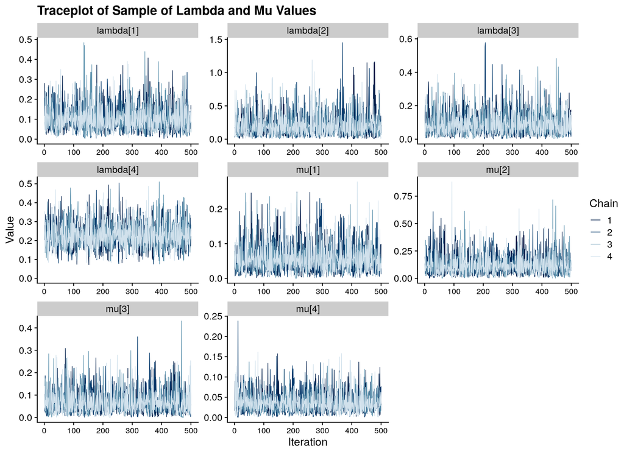

```r
parameter_subset <- c(
  "lambda[1]", "lambda[2]", "lambda[3]", "lambda[4]",
  "mu[1]",     "mu[2]",     "mu[3]",     "mu[4]"
  )

pnbd_nonhier_fixed_stanfit$draws(inc_warmup = FALSE) |>
  mcmc_trace(pars = parameter_subset) +
  expand_limits(y = 0) +
  labs(
    x = "Iteration",
    y = "Value",
    title = "Traceplot of Sample of Lambda and Mu Values"
    ) +
  theme(axis.text.x = element_text(size = 10))
```

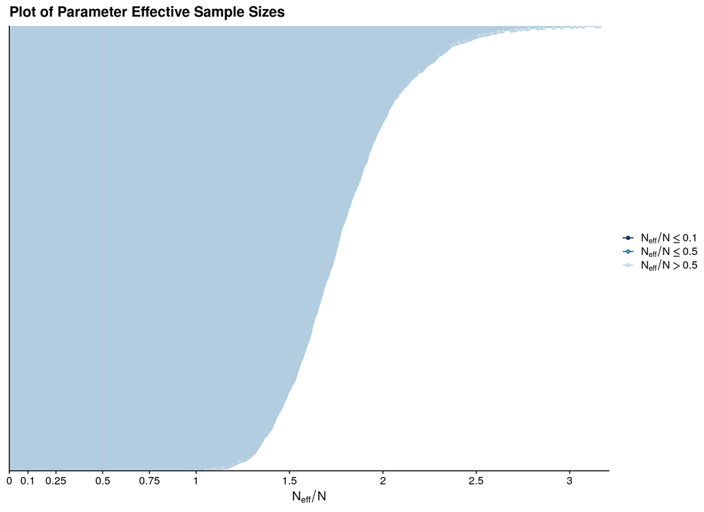

```r
pnbd_nonhier_fixed_stanfit |>
  neff_ratio(pars = c("lambda", "mu")) |>
  as.numeric() |>
  mcmc_neff() +
    ggtitle("Plot of Parameter Effective Sample Sizes")
```

## 2.2 Check Model Fit

As we are still working with synthetic data, we know the true values for each customer and so we can check how good our model is at recovering the true values on a customer-by-customer basis.

As in previous workbooks, we build our validation datasets and then check the distribution of $q$-values for both $\lambda$ and $\mu$ across the customer base.

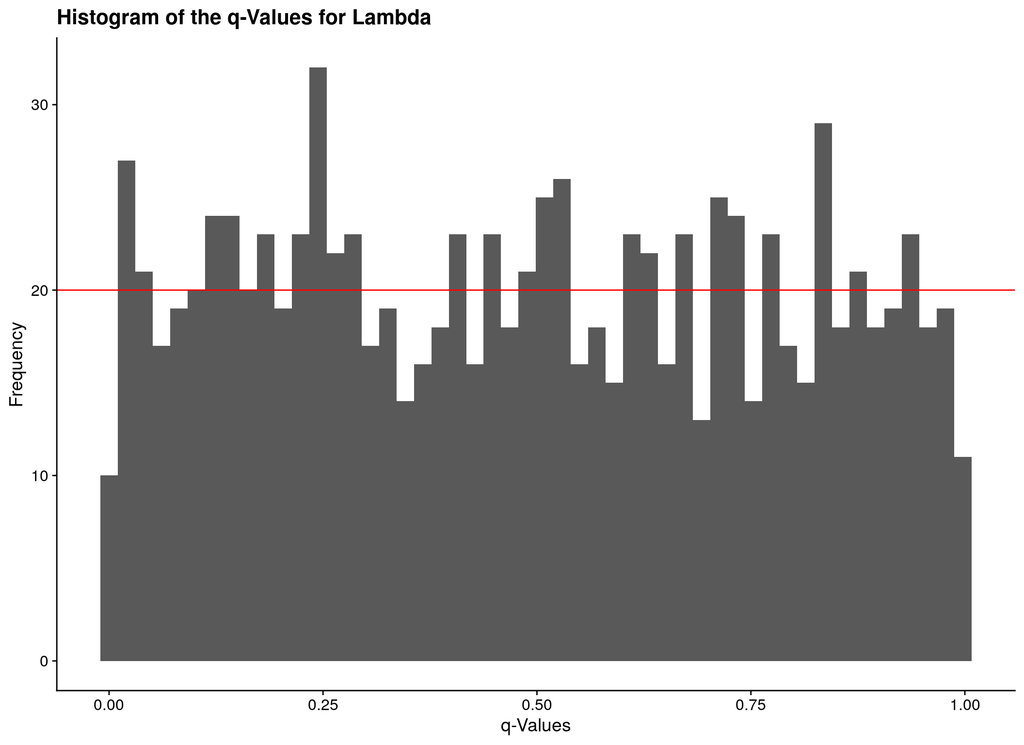

```r
pnbd_nonhier_fixed_valid_lst <- create_pnbd_posterior_validation_data(
  stanfit       = pnbd_nonhier_fixed_stanfit,
  data_tbl      = customer_fit_stats_tbl,
  simparams_tbl = customer_simparams_tbl
  )

pnbd_nonhier_fixed_valid_lst$lambda_qval_plot |> plot()
```

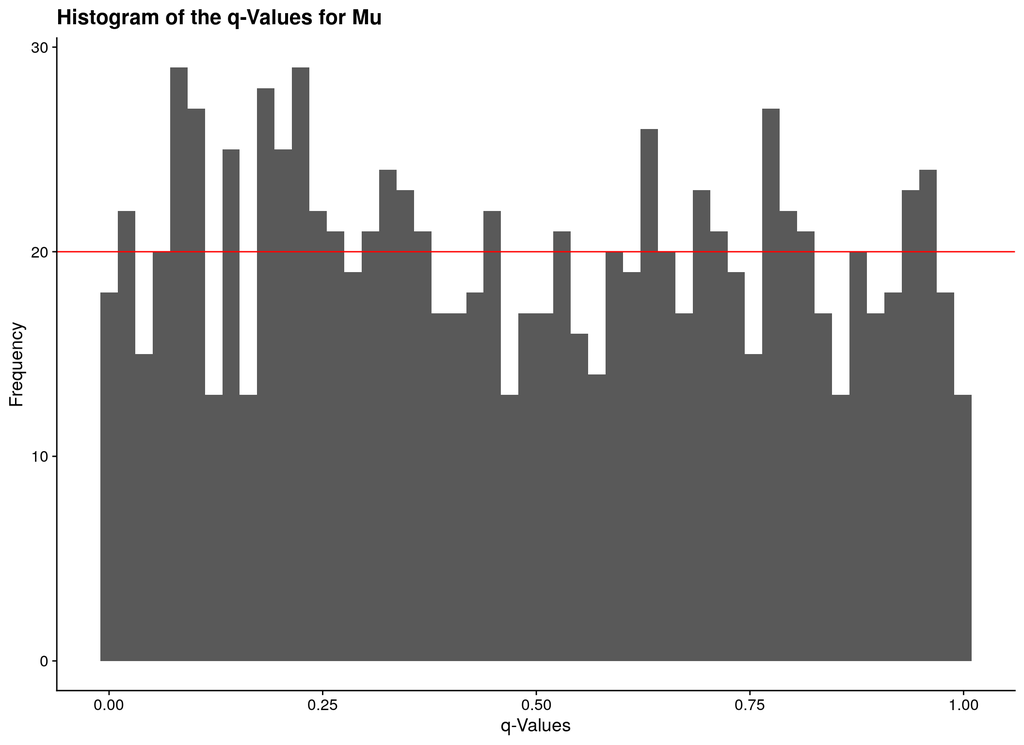

```r
pnbd_nonhier_fixed_valid_lst$mu_qval_plot |> plot()
```

These plots looks like the model is recovering the parameters well, but cannot rely on this approach once we use real data so we will stop using this now.

Instead, we will look at using our posterior sample to generate data and compare this simulated data against the data we fit. This procedure is similar to what we did before but now we focus on in sample data rather than using validation data.

```r
sim_stats_tbl <- construct_pnbd_posterior_statistics(
  stanfit         = pnbd_nonhier_fixed_stanfit,
  fitdata_tbl     = customer_fit_stats_tbl
  )

sim_stats_tbl |> glimpse()
```

```
Rows: 2,000,000
Columns: 6
$ customer_id    <chr> "C202001_0025", "C202001_0025", "C202001_0025", "C20200…
$ first_tnx_date <dttm> 2020-01-01 07:41:56, 2020-01-01 07:41:56, 2020-01-01 0…
$ draw_id        <int> 1, 2, 3, 4, 5, 6, 7, 8, 9, 10, 11, 12, 13, 14, 15, 16, …
$ post_lambda    <dbl> 0.2808830, 0.1477840, 0.0530641, 0.0954510, 0.0834540, …
$ post_mu        <dbl> 0.02546980, 0.03537270, 0.00776253, 0.05982250, 0.05415…
$ p_alive        <dbl> 4.43688e-11, 7.56369e-07, 4.05865e-02, 4.16305e-06, 1.8…
```

We then use these posterior statistics as inputs to our simulations to help us assess the in-sample quality of fit.

```r
plan(multisession)

fit_label <- "pnbd_nonhier_fixed"

precompute_dir <- glue("precompute/{fit_label}")

ensure_exists_precompute_directory(precompute_dir)
```

```
[1] TRUE
```

```r
precomputed_tbl <- dir_ls(glue("{precompute_dir}")) |>
  as.character() |>
  enframe(name = NULL, value = "sim_file")

pnbd_nonhier_fixed_validsims_index_tbl <- sim_stats_tbl |>
  group_nest(customer_id, .key = "cust_params") |>
  mutate(
    sim_file = glue(
      "{precompute_dir}/sims_fit_{fit_label}_{customer_id}.rds"
      )
    )


runsims_tbl <- pnbd_nonhier_fixed_validsims_index_tbl |>
  anti_join(precomputed_tbl, by = "sim_file")

if(nrow(runsims_tbl) > 0) {
  pnbd_nonhier_fixed_validsims_index_tbl <- runsims_tbl |>
    mutate(
      chunk_data = future_map2(
        sim_file, cust_params,
        run_pnbd_simulations_chunk,

        end_dttm   = as.POSIXct(use_fit_end_date),

        .options = furrr_options(
          globals  = c(
            "rbernoulli", "calculate_event_times", "rgamma_mucv",
            "gamma_mucv2shaperate", "generate_pnbd_validation_transactions"
            ),
          packages   = c("tidyverse", "fs"),
          scheduling = Inf,
          seed       = 421
          ),
        .progress = TRUE
        )
      )
}


pnbd_nonhier_fixed_validsims_index_tbl |> glimpse()
```

```
Rows: 1,000
Columns: 4
$ customer_id <chr> "C202001_0025", "C202001_0084", "C202001_0091", "C202001_0…
$ cust_params <list<tibble[,5]>> [<tbl_df[2000 x 5]>], [<tbl_df[2000 x 5]>], […
$ sim_file    <glue> "precompute/pnbd_nonhier_fixed/sims_fit_pnbd_nonhier_fixe…
$ chunk_data  <list> TRUE, TRUE, TRUE, TRUE, TRUE, TRUE, TRUE, TRUE, TRUE, TRU…
```

We now want to load up the summary statistics for each of our customers for later analysis.

```r
retrieve_sim_stats <- ~ .x |>
  read_rds() |>
  select(draw_id, sim_tnx_count, sim_tnx_last)


pnbd_nonhier_fixed_simstats_tbl <- pnbd_nonhier_fixed_validsims_index_tbl |>
  mutate(
    sim_data = future_map(
      sim_file, retrieve_sim_stats,

      .options = furrr_options(
        globals    = FALSE,
        packages   = c("tidyverse", "fs"),
        scheduling = Inf
        ),
      .progress = TRUE
      )
    ) |>
  select(customer_id, sim_data) |>
  unnest(sim_data)

pnbd_nonhier_fixed_simstats_tbl |> glimpse()
```

```
Rows: 2,000,000
Columns: 4
$ customer_id   <chr> "C202001_0025", "C202001_0025", "C202001_0025", "C202001…
$ draw_id       <int> 1, 2, 3, 4, 5, 6, 7, 8, 9, 10, 11, 12, 13, 14, 15, 16, 1…
$ sim_tnx_count <int> 9, 9, 4, 4, 2, 1, 1, 2, 0, 3, 1, 0, 0, 1, 0, 0, 2, 1, 1,…
$ sim_tnx_last  <dttm> 2020-07-15 05:28:11, 2021-01-07 03:33:46, 2020-12-02 02…
```

# 3 R Environment

```r
options(width = 120L)
```

```r
options(width = 80L)
```